# Getting started: Simple tree searches

Martin R. Smith

2025-06-10

“TreeSearch” is an R package that allows, among other things, parsimony search on morphological datasets that contain inapplicable data, using the algorithm proposed by Brazeau, Guillerme and Smith (2019) and implemented in the ‘MorphyLib’ C library (Brazeau, Smith, & Guillerme, 2017) ([details](https://rawgit.com/TGuillerme/Inapp/c4d502fa4ae3702eb207b2da3a692e469ba3b6ab/inst/gitbook/_book/index.html)).

## Getting started

A companion vignette gives details on installing the package and getting up and running.

Launch an interactive ‘app’ in your browser by typing `TreeSearch::EasyTrees()` at the R / RStudio command line.

This will allow you to load data from a file, modify search settings, and explore the distribution of most parsimonious trees in tree space.

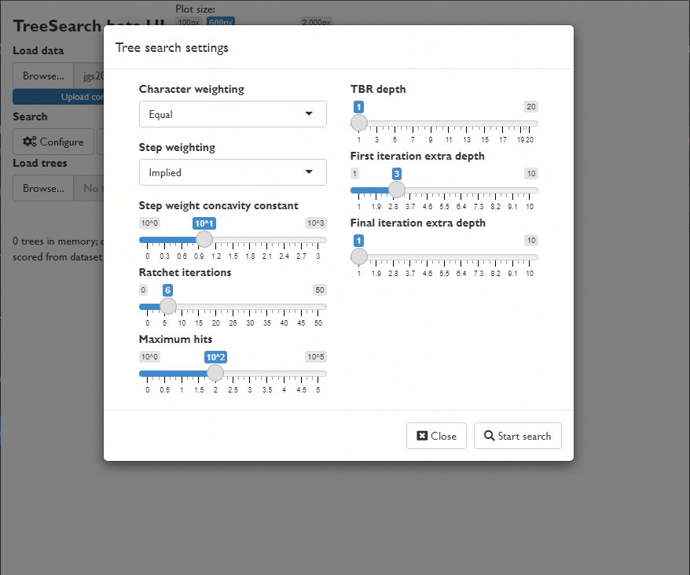

Starting parsimony search

View a consensus tree and explore the position of rogue taxa (Smith, 2022b):

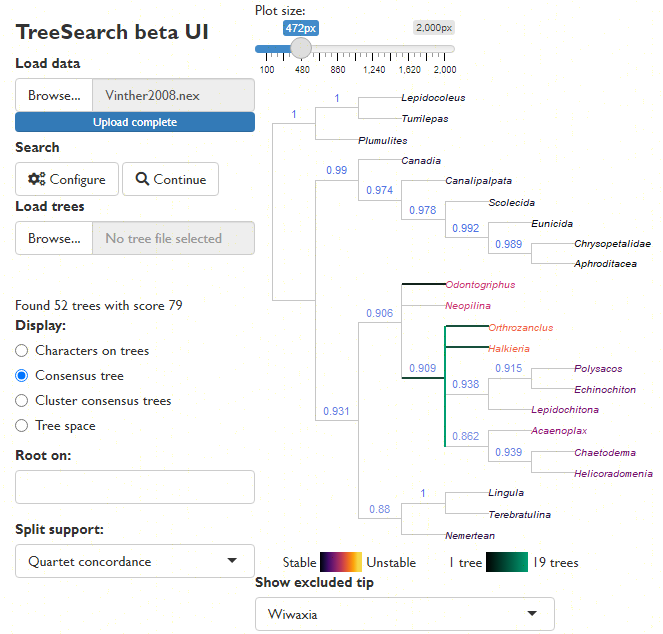

Visualizing position of rogue taxon on search result consensus tree

Explore the distribution of trees (whether found by search or loaded from file) in tree space (Smith, 2022a), and evaluate search progress (Whidden & Matsen, 2015):

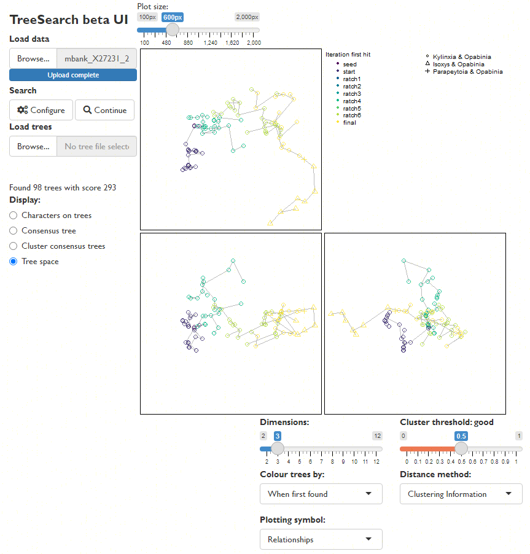

Evaluating search progress using tree space

Map characters on a chosen tree, using character and taxon notes imported from a Nexus file, if present. (This is designed to be interoperable with [MorphoBank](https://morphobank.org) matrices.)

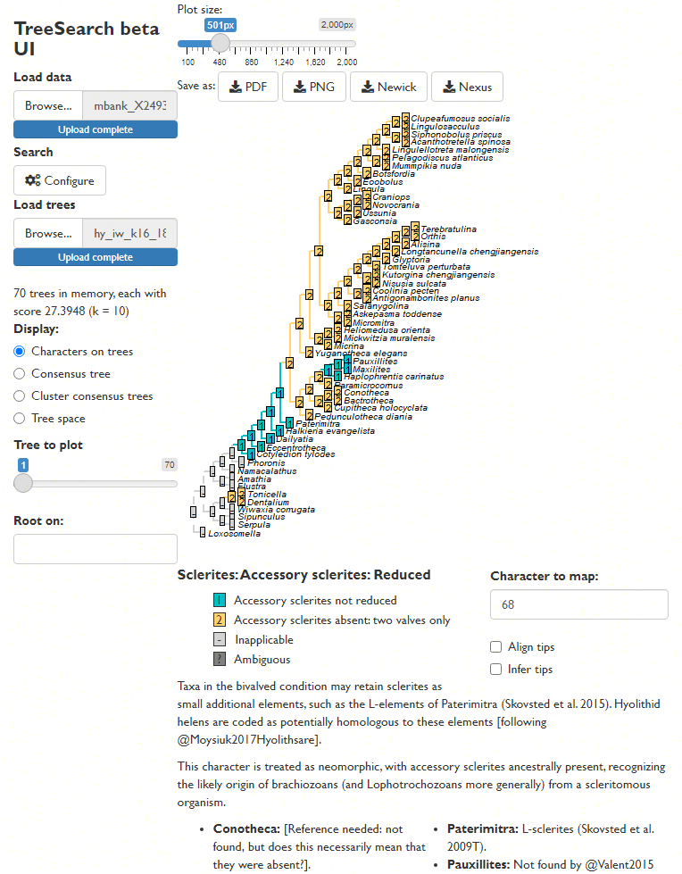

Mapping character reconstructions

Trees can be saved as images, or in Nexus/Newick for further analysis.

## Command line tree search

You can also run tree searches using the R command line. Once installed, load the “TreeSearch” package into R using

```r
library("TreeSearch")
```

You can [load your own dataset](https://ms609.github.io/TreeTools/articles/load-data.html), but for now, we’ll use the Vinther *et al.* (2008) dataset that comes bundled with “TreeSearch”.

This dataset is small enough that it runs reasonably quickly, but its phylogenetic signal is obscure enough that it can require Ratchet searches to escape from local optima.

```r
vinther <- TreeSearch::inapplicable.phyData[["Vinther2008"]]
```

```r
# Set a random seed so that random functions in this document are reproducible
RNGversion("3.5.0")
set.seed(0)
```

We can conduct a basic parsimony search with:

```r
bestTrees <- MaximizeParsimony(vinther)
```

It can be instructive to inspect the progress of tree search.

```r
firstHit <- attr(bestTrees, "firstHit")
firstHit
```

```
##   seed  start ratch1 ratch2 ratch3 ratch4 ratch5 ratch6 ratch7  final
##      0     27      0      0     15      2      6      0      1      0
```

Advanced users might wish to visualize the progress of tree search by mapping tree space:

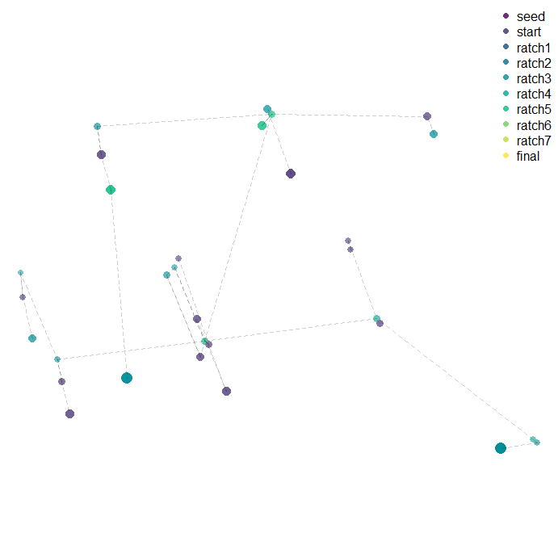

```r
distances <- TreeDist::ClusteringInfoDistance(bestTrees)
searchStages <- length(firstHit)
map <- cmdscale(distances, k = 3)
cols <- hcl.colors(searchStages, alpha = 0.8)
par(mar = rep(0, 4))
TreeDist::Plot3(map,
                col = cols[rep(seq_along(firstHit), firstHit)],
                pch = 16, cex = 2,
                axes = FALSE, xlab = "", ylab = "", asp = 1)
TreeTools::MSTEdges(distances, plot = TRUE, map[, 1], map[, 2],
                    col = "#00000030", lty = 2)
legend("topright", names(firstHit), col = cols, pch = 16, bty = "n")
```

A quick glance suggests that early ratchet iterations captured a large part of the diversity of optimal trees, and that iterations aren’t getting stuck in local optima – though conscientious users will [ensure that the mapping of tree space is meaningful and adequate](https://ms609.github.io/TreeDist/articles/treespace.html) to detect structure before making any firm conclusions (Smith, 2022a).

To be thorough, we might consider continuing the search for a little longer, fine-tuning the search parameters:

```r
bestTrees <- MaximizeParsimony(vinther, tree = bestTrees,
                               ratchIter = 6L,
                               tbrIter = 4L,
                               finalIter = 3L,
                               maxHits = 80L)
```

As it happens, the best tree for this dataset has a score of 79 under equal weights parsimony.

We can plot the best tree(s) that we’ve found, and check its parsimony score (length):

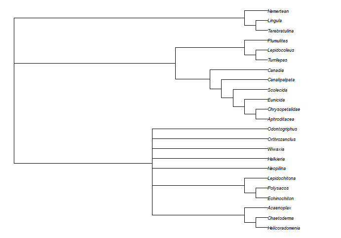

```r
par(mar = rep(0.25, 4), cex = 0.75) # make plot easier to read
plot(ape::consensus(bestTrees))
```

```r
TreeLength(bestTrees[[1]], vinther)
```

```
## [1] 79
```

### Evaluating clade support

We might be interested in labelling clades with their frequency among the sampled most-parsimonious trees:

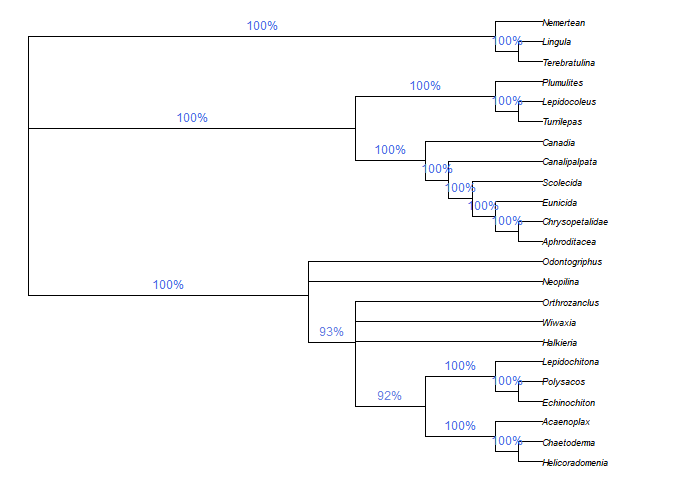

```r
par(mar = rep(0.25, 4), cex = 0.75) # make plot easier to read
majCons <- ape::consensus(bestTrees, p = 0.5)
splitFreqs <- TreeTools::SplitFrequency(majCons, bestTrees) / length(bestTrees)
plot(majCons)
TreeTools::LabelSplits(majCons, round(splitFreqs * 100), unit = "%",
                       col = TreeTools::SupportColor(splitFreqs),
                       frame = "none", pos = 3L)
```

This approach is a sensible way to analyse clade credibility when the frequency of a split corresponds to its probability, as is the case in a Bayesian posterior sample of trees. This is not the case, however, in sets of most parsimonious trees.

Imagine if our set of most parsimonious trees was expanded to include a single additional tree in which *Halkieria* was sister to the brachiopod *Terebratulina* (close to the outgroup). We would then be in a situation in which *Halkieria* may be a brachiopod – in which case a single interpretation of molluscan relationships is most parsimonious – or may be a mollusc, in which case its mosaic of characters can be reconciled with molluscs in a number of equally-parsimonious ways. Neither interpretation should be considered more or less plausible, even if we observe more unique most parsimonious trees in which *Halkieria* is a mollusc simply because of the greater resultant uncertainty in the placement of taxa such as *Odontogriphus* and *Wiwaxia*.

A more instructive measure of clade support can be generated using Jackknife resampling. The `Resample()` [manual page](https://ms609.github.io/TreeSearch/reference/MaximizeParsimony.html) has suggestions for appropriate numbers of replicates and search intensity, and instructions for calculating bootstrap support; the code here gives a quick-to-run jackknife framework that can be adapted to the requirements of a particular dataset.

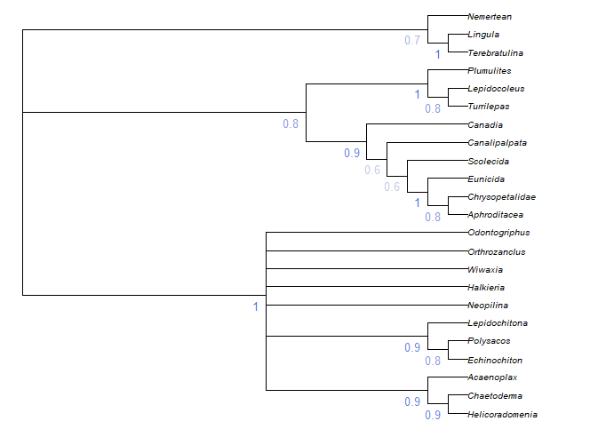

```r
nReplicates <- 10
jackTrees <- lapply(logical(nReplicates), function (x)
  Resample(vinther, bestTrees, ratchIter = 0, tbrIter = 1, maxHits = 4,
           verbosity = 0)
)

strict <- ape::consensus(bestTrees, p = 1)

par(mar = rep(0, 4), cex = 0.8)
# Take the strict consensus of all trees for each replicate
JackLabels(strict, lapply(jackTrees, ape::consensus)) -> XX
```

Jackknife and bootstrap support values give an indication of the volume of data that supports each node, but don’t necessarily indicate whether the data are unanimous on the existence of a clade: a high bootstrap support value could indicate a large number of characters supporting a clade, and an only slightly smaller number of characters contradicting it.

“TreeSearch” implements a number of concordance measures that aim to indicate whether a dataset is unanimous or divided in support of a grouping, independently of the method of tree reconstruction.

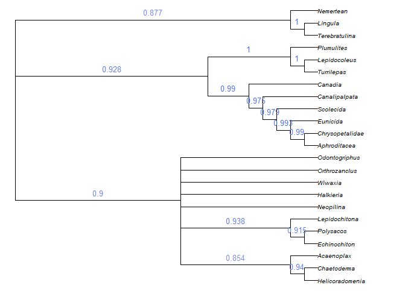

```r
concordance <- QuartetConcordance(strict, vinther)

# Alternative measures:
# concordance <- ClusteringConcordance(strict, vinther)
# concordance <- PhylogeneticConcordance(strict, vinther)

par(mar = rep(0, 4), cex = 0.8)
plot(strict)
TreeTools::LabelSplits(strict, signif(concordance, 3),
                       col = TreeTools::SupportColor(concordance / max(concordance)),
                       frame = "none", pos = 3L)
```

### Exploring taxon stability

Measure of clade support can only captures one aspect of the uncertainty in a set of trees. Often one “rogue” taxon with an uncertain position can mask agreement in the relationships of other taxa (Smith, 2022b). The potential impact of rogue taxa can be explored by colouring individual tips according to their stability in the tree set:

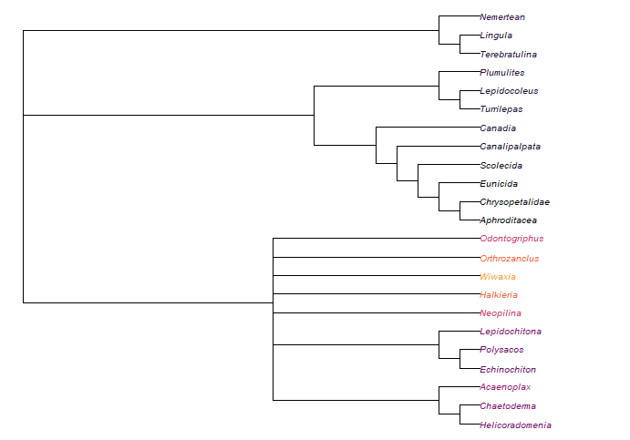

```r
par(mar = rep(0, 4), cex = 0.8)

plot(strict, tip.color = Rogue::ColByStability(bestTrees))
```

Would removing an unstable taxon reveal hidden support for relationships at the base of Mollusca? We can test to see whether the removal of a taxon from a summary tree is justified using:

```r
Rogue::QuickRogue(bestTrees, p = 1)
```

```
##   num taxNum   taxon rawImprovement       IC
## 1   0   <NA>    <NA>             NA 154.5491
## 2   1     21 Wiwaxia       14.32221 168.8713
```

In this case, dropping *Wiwaxia* would improve the resolution of the strict consensus by enough to justify the loss of the information regarding its own position (a net gain of 14.3 bits). The most informative single summary tree is thus provided by:

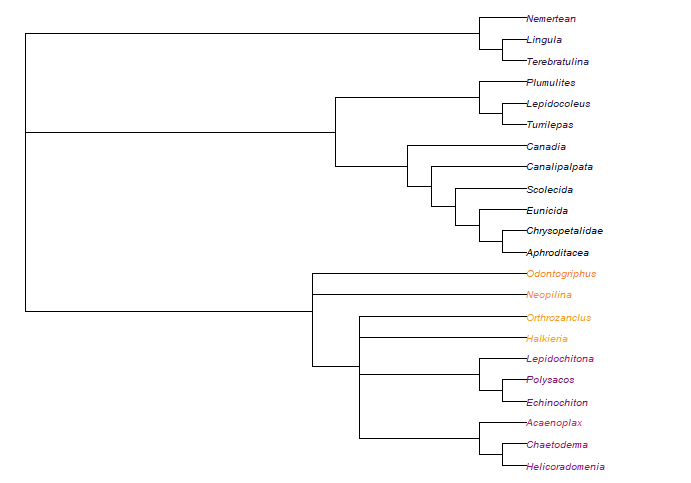

```r
par(mar = rep(0, 4), cex = 0.8)
noWiwaxia <- lapply(bestTrees, TreeTools::DropTip, "Wiwaxia")
plot(ape::consensus(noWiwaxia), tip.color = Rogue::ColByStability(noWiwaxia))
```

This reveals that all trees agree that *Halkieria* and *Orthrozanclus* are closer to aculiferan molluscs than *Odontogriphus* and *Neopilina*, a fact masked in the strict consensus due to the uncertain position of *Wiwaxia*.

We can see where *Wiwaxia* would plot on this tree using:

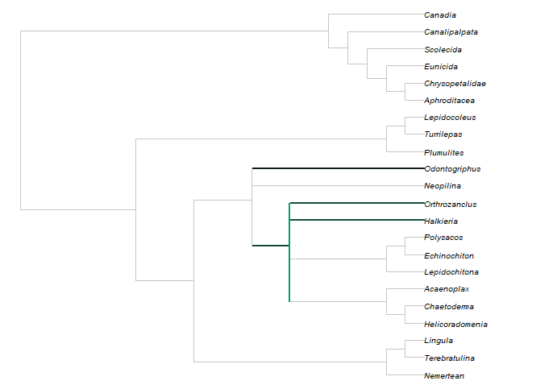

```r
par(mar = rep(0, 4), cex = 0.8)
xx <- TreeTools::RoguePlot(bestTrees, "Wiwaxia", p = 1)
```

Brighter greens indicate that more trees contained *Wiwaxia* in this position.

More details on rogue taxon identification are available in the package [“Rogue”](https://ms609.github.io/Rogue/).

## Implied weighting

Equal weights produces trees that are less accurate and less precise than implied weights (Smith, 2019); equally weighted analysis should never be conducted without also considering the results of implied weights (Goloboff, 1993, 1997), ideally under a range of concavity constants (cf. Smith & Ortega-Hernández, 2014).

Implied weights can be activated by simply specifying a value of the concavity constant, *k*:

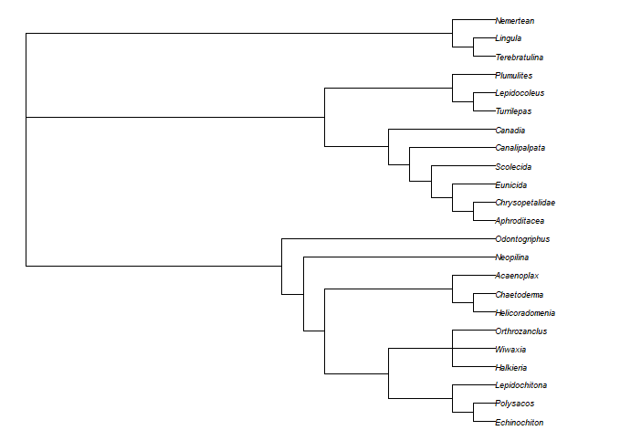

```r
iwTrees <- MaximizeParsimony(vinther, concavity = 10)
par(mar = rep(0.25, 4), cex = 0.75) # make plot easier to read
plot(ape::consensus(iwTrees))
```

Note that we recommend a default value of 10, somewhat higher than the default of 3 in TNT; this low default gives poorer results in many settings (Goloboff, Torres, & Arias, 2018; Smith, 2019). Better still is to use multiple values and compare the results, perhaps in [Tree space](https://ms609.github.io/TreeDist/articles/treespace.html). Even better (?) is to use [profile parsimony](https://ms609.github.io/TreeSearch/articles/profile.html).

## Constraining a search

It is sometimes legitimate to insist that trees must contain a certain clade. Doing so reduces the number of tree rearrangements that are considered, and can this speed up tree search.

`MaximizeParsimony()` will attempt to find a starting tree that satisfies the constraints, but if it cannot, it may be necessary to specify one manually – perhaps after checking that no constraints are contradictory.

Here’s a simple example on six taxa that enforces the bipartition ab | cdef:

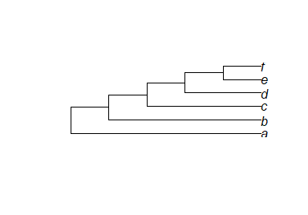

```r
library("TreeTools", quietly = TRUE)
constraint <- MatrixToPhyDat(c(a = 1, b = 1, c = 0, d = 0, e = 0, f = 0))
characters <- MatrixToPhyDat(matrix(
  c(0, 1, 1, 1, 0, 0,
    1, 1, 1, 0, 0, 0), ncol = 2,
  dimnames = list(letters[1:6], NULL)))
plot(MaximizeParsimony(characters, constraint = constraint,
                       verbosity = -1)[[1]])
```

Here’s a more complex example that imposes the splits `ab | cef` and `abcd | ef`, whilst allowing `g` to plot anywhere on the tree:

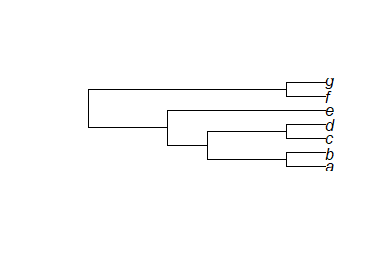

```r
characters <- MatrixToPhyDat(matrix(
  c(0, 0, 1, 1, 1, 1, 1,
    1, 1, 1, 1, 0, 0, 0), ncol = 2,
  dimnames = list(letters[1:7], NULL)))
constraint <- MatrixToPhyDat(matrix(
  c(0, 0, 1, "?", 1, 1,
    1, 1, 1,   1, 0, 0), ncol = 2,
  dimnames = list(letters[1:6], NULL)))
plot(MaximizeParsimony(characters, constraint = constraint,
                       verbosity = -1)[[1]])
```

Constraints can also be loaded from a Nexus file with `constraint <- TreeTools::ReadAsPhyDat("constraint_file.nex")`.

## Where next?

- [Documentation home](https://ms609.github.io/TreeSearch/)
- Guide to installation
- Search for trees using
  - standard parsimony (corrected for inapplicable data)
  - profile parsimony
  - custom optimality criteria
- Explore the distribution of optimal trees in mappings

## References

Brazeau, M. D., Guillerme, T., & Smith, M. R. (2019). An algorithm for morphological phylogenetic analysis with inapplicable data. *Systematic Biology*, *68*, 619–631. doi: 10.1093/sysbio/syy083

Brazeau, M. D., Smith, M. R., & Guillerme, T. (2017). *MorphyLib: A library for phylogenetic analysis of categorical trait data with inapplicability*. doi: 10.5281/zenodo.815372

Goloboff, P. A. (1993). Estimating character weights during tree search. *Cladistics*, *9*(1), 83–91. doi: 10.1111/j.1096-0031.1993.tb00209.x

Goloboff, P. A. (1997). Self-weighted optimization: tree searches and character state reconstructions under implied transformation costs. *Cladistics*, *13*(3), 225–245. doi: 10.1111/j.1096-0031.1997.tb00317.x

Goloboff, P. A., Torres, A., & Arias, J. S. (2018). Weighted parsimony outperforms other methods of phylogenetic inference under models appropriate for morphology. *Cladistics*, *34*(4), 407–437. doi: 10.1111/cla.12205

Smith, M. R. (2019). Bayesian and parsimony approaches reconstruct informative trees from simulated morphological datasets. *Biology Letters*, *15*(2), 20180632. doi: 10.1098/rsbl.2018.0632

Smith, M. R. (2022a). Robust analysis of phylogenetic tree space. *Systematic Biology*, *71*(5), 1255–1270. doi: 10.1093/sysbio/syab100

Smith, M. R. (2022b). Using information theory to detect rogue taxa and improve consensus trees. *Systematic Biology*, *71*(5), 1088–1094. doi: 10.1093/sysbio/syab099

Smith, M. R., & Ortega-Hernández, J. (2014). *Hallucigenia*’s onychophoran-like claws and the case for Tactopoda. *Nature*, *514*(7522), 363–366. doi: 10.1038/nature13576

Vinther, J., Van Roy, P., & Briggs, D. E. G. (2008). Machaeridians are Palaeozoic armoured annelids. *Nature*, *451*(7175), 185–188. doi: 10.1038/nature06474

Whidden, C., & Matsen, F. A. (2015). Quantifying MCMC exploration of phylogenetic tree space. *Systematic Biology*, *64*(3), 472–491. doi: 10.1093/sysbio/syv006